# Transgression Proof of Concept Analysis

This notebook holds the initial analysis for Transgression Condemnation Project on the data collected by Joe et al.

## Data Description

Remember that all the tweets that were not retweets had 0 favoritesCount and retweetCount. So we decided to limit this analysis to retweets only (RT)

| Description | Count |
| --- | --- |
| All Tweets | 14,798,103 |
| Tweets | 4,683,905 |
| Retweet (RT) | 10,114,198 |
| Condemnation RT (CRT) | 5,665,504 |
| Valid Time (VT) + CRT | 3,126,598 |
| Severity Rating (SR) + VT + CRT | 3,072,275 |

We will work on the set of SR+VT+CRT (n= 3,072,275). If we want to take political ideology into account more filtering has to be done. For each retweet we have two users. The user that has written the original tweet (RT_user_id) and the user that has retweeted the original tweet (user_id). Recall that for political ideology estimation we need the users to follow some political accounts. Here I’ve se the threshold to users following only one political account. Remember that as of now I don’t have data only for 460 political accounts (out of the 613)

| Description | Count |
| --- | --- |
| Unique user_ids in SR + VT + CRT | 776,698 |
| Unique user_ids in SR + VT + CRT who follow at least one political account (from 460) | 210,872 |
| retweets in SR+VT+CRT from user_ids who follow at least one political account | 1,299,095 |
| Unique RT_user_ids in SR + VT + CRT | 73,573 |
| Unique RT_user_ids in SR + VT + CRT who follow at least one political account (from 460) | 24,003 |
| retweets in SR+VT+CRT from user_ids who follow at least one political account | 1,753,565 |

```r
twitter_file = "../data/filtered_condemnation_RTs.csv"
user_id_ideology_file = "../data/user_id_political_ideologies.rdata"
RT_user_id_ideology_file = "../data/RT_user_id_political_ideologies.rdata"

library(ggplot2)
library(MASS)
library(dplyr)
library(glmmTMB)
library(AER)
library(pscl)
# -----------------------------loading data------------------------------
twitter_df = read.csv(twitter_file)

load(RT_user_id_ideology_file)
RT_user_ideologies <- res
load(user_id_ideology_file)
og_user_ideologies <- res

user_ideology_estimates = og_user_ideologies$rowcoord[,1]
user_ids = og_user_ideologies$rownames
RT_user_ideology_estimates = RT_user_ideologies$rowcoord[,1]
RT_user_ids = RT_user_ideologies$rownames

user_ideology_df = data.frame(user_ideology_estimates, user_ids)
RT_user_ideology_df = data.frame(RT_user_ideology_estimates, RT_user_ids)


names(user_ideology_df)[2]<- "user_id"
twitter_df <- merge(twitter_df,user_ideology_df,by.x = "user_id")
```

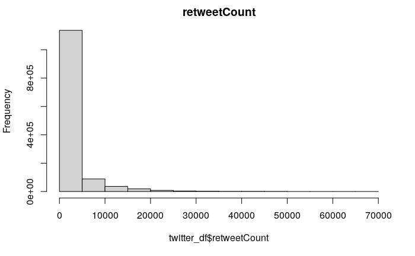

```r
hist(twitter_df$retweetCount, main="retweetCount")
```

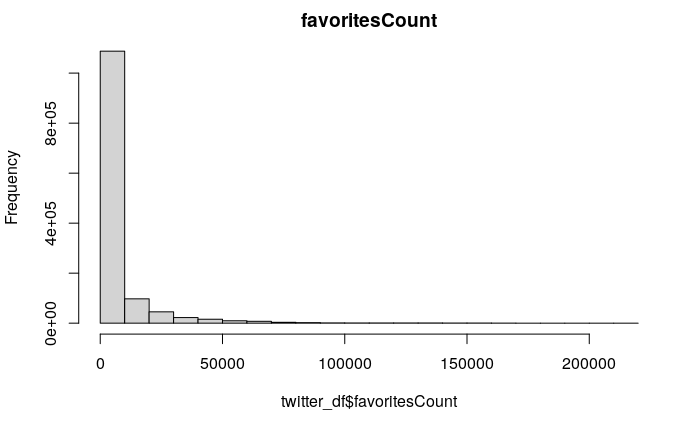

```r
hist(twitter_df$favoritesCount, main="favoritesCount")
```

## Modeling FavoritesCount

### Without the political idoelogy

```r
Y = cbind(twitter_df$favoritesCount)
colnames(Y) <- c("FavoritesCount")    # Applying colnames
X = cbind(twitter_df$severity_prediction)
colnames(X) <- c("Severity")    # Applying colnames
summary(Y)
```

```
 FavoritesCount
 Min.   :     0
 1st Qu.:   105
 Median :   985
 Mean   :  6310
 3rd Qu.:  5506
 Max.   :210727
```

```r
summary(X)
```

```
    Severity
 Min.   :0.0000
 1st Qu.:1.0000
 Median :1.0000
 Mean   :0.9101
 3rd Qu.:1.0000
 Max.   :2.0000
```

```r
#----------------------------poisson----------------------

p <- glm(Y~X, family = poisson)
summary(p)
```

```
Call:
glm(formula = Y ~ X, family = poisson)

Deviance Residuals:
    Min       1Q   Median       3Q      Max
-134.17  -106.22   -81.31    -8.35  1098.01

Coefficients:
             Estimate Std. Error z value Pr(>|z|)
(Intercept) 8.419e+00  2.288e-05  368046   <2e-16 ***
X           3.430e-01  1.967e-05   17433   <2e-16 ***
---
Signif. codes:  0 ‘***’ 0.001 ‘**’ 0.01 ‘*’ 0.05 ‘.’ 0.1 ‘ ’ 1

(Dispersion parameter for poisson family taken to be 1)

    Null deviance: 2.1093e+10  on 1299094  degrees of freedom
Residual deviance: 2.0789e+10  on 1299093  degrees of freedom
AIC: 2.08e+10

Number of Fisher Scoring iterations: 6
```

Running overdispersion test

```r
#--------------------------Dispersion test-------------------
# from AER package

dispersiontest(p)
```

```
    Overdispersion test

data:  p
z = 223.7, p-value < 2.2e-16
alternative hypothesis: true dispersion is greater than 1
sample estimates:
dispersion
  30796.72
```

```r
dispersiontest(p, trafo = 2)
```

```
    Overdispersion test

data:  p
z = 235.68, p-value < 2.2e-16
alternative hypothesis: true alpha is greater than 0
sample estimates:
   alpha
5.037348
```

This result tells us that we can’t use a poisson distribution to model our data. Poission distribution assumes equal mean and variance for the data.

```r
#---------------------------negative binomial---------------
negbin <- glm.nb(Y ~ X)
summary(negbin)
```

```
Call:
glm.nb(formula = Y ~ X, init.theta = 0.2905858914, link = log)

Deviance Residuals:
    Min       1Q   Median       3Q      Max
-2.4422  -1.3424  -0.7625  -0.0619   4.7267

Coefficients:
            Estimate Std. Error z value Pr(>|z|)
(Intercept) 8.492263   0.003098 2741.28   <2e-16 ***
X           0.267181   0.002896   92.25   <2e-16 ***
---
Signif. codes:  0 ‘***’ 0.001 ‘**’ 0.01 ‘*’ 0.05 ‘.’ 0.1 ‘ ’ 1

(Dispersion parameter for Negative Binomial(0.2906) family taken to be 1)

    Null deviance: 1775895  on 1299094  degrees of freedom
Residual deviance: 1764997  on 1299093  degrees of freedom
AIC: 23039984

Number of Fisher Scoring iterations: 1

              Theta:  0.290586
          Std. Err.:  0.000290

 2 x log-likelihood:  -23039978.221000
```

```r
#----------------------------hurdle (truncated poisson) model---------------
hpossion <- hurdle(Y~X | X, link="logit", dist="poisson") # second x affect 0 or positive decision
summary(hpossion)
```

```
Call:
hurdle(formula = Y ~ X | X, dist = "poisson", link = "logit")

Pearson residuals:
     Min       1Q   Median       3Q      Max
 -6.2556  -6.1370  -5.2497  -0.6554 283.4561

Count model coefficients (truncated poisson with log link):
             Estimate Std. Error z value Pr(>|z|)
(Intercept) 8.444e+00  2.288e-05  369103   <2e-16 ***
X           3.430e-01  1.968e-05   17433   <2e-16 ***
Zero hurdle model coefficients (binomial with logit link):
            Estimate Std. Error z value Pr(>|z|)
(Intercept) 3.667743   0.010721 342.111   <2e-16 ***
X           0.001786   0.010028   0.178    0.859
---
Signif. codes:  0 '***' 0.001 '**' 0.01 '*' 0.05 '.' 0.1 ' ' 1

Number of iterations in BFGS optimization: 6
Log-likelihood: -1.019e+10 on 4 Df
```

```r
#----------------------------hurdle (truncated negative binomial) model---------------
hpossion <- hurdle(Y~X | X, link="logit", dist="negbin") # second x affect 0 or positive decision
summary(hpossion)
```

```
Call:
hurdle(formula = Y ~ X | X, dist = "negbin", link = "logit")

Pearson residuals:
     Min       1Q   Median       3Q      Max
-0.50211 -0.49157 -0.42086 -0.05525 21.16156

Count model coefficients (truncated negbin with log link):
             Estimate Std. Error z value Pr(>|z|)
(Intercept)  8.406095   0.003155 2664.20   <2e-16 ***
X            0.272569   0.002818   96.72   <2e-16 ***
Log(theta)  -1.486414   0.001737 -855.63   <2e-16 ***
Zero hurdle model coefficients (binomial with logit link):
            Estimate Std. Error z value Pr(>|z|)
(Intercept) 3.667743   0.010721 342.111   <2e-16 ***
X           0.001786   0.010028   0.178    0.859
---
Signif. codes:  0 '***' 0.001 '**' 0.01 '*' 0.05 '.' 0.1 ' ' 1

Theta: count = 0.2262
Number of iterations in BFGS optimization: 22
Log-likelihood: -1.149e+07 on 5 Df
```

```r
# ----------------------------zero inflated =poisson -----------------------------------
zip <- zeroinfl(Y~X | X, link="logit", dist="poisson")
summary(zip)
```

```
Call:
zeroinfl(formula = Y ~ X | X, dist = "poisson", link = "logit")

Pearson residuals:
     Min       1Q   Median       3Q      Max
 -6.2556  -6.1370  -5.2497  -0.6554 283.4561

Count model coefficients (poisson with log link):
             Estimate Std. Error z value Pr(>|z|)
(Intercept) 8.444e+00  2.288e-05  369103   <2e-16 ***
X           3.430e-01  1.968e-05   17433   <2e-16 ***

Zero-inflation model coefficients (binomial with logit link):
             Estimate Std. Error  z value Pr(>|z|)
(Intercept) -3.667743   0.010721 -342.111   <2e-16 ***
X           -0.001786   0.010028   -0.178    0.859
---
Signif. codes:  0 '***' 0.001 '**' 0.01 '*' 0.05 '.' 0.1 ' ' 1

Number of iterations in BFGS optimization: 1
Log-likelihood: -1.019e+10 on 4 Df
```

```r
#----------------------------zero inflated negative binomial----------------
zinb <- zeroinfl(Y~X | X, link="logit", dist="negbin")
```

### With the user political idoelogy

```r
Y = cbind(twitter_df$favoritesCount)
colnames(Y) <- c("FavoritesCount")    # Applying colnames
X = cbind(twitter_df$severity_prediction, twitter_df$user_ideology_estimates)
colnames(X) <- c("Severity", "UserIdeologyEstimate")    # Applying colnames
summary(Y)
```

```
 FavoritesCount
 Min.   :     0
 1st Qu.:   105
 Median :   985
 Mean   :  6310
 3rd Qu.:  5506
 Max.   :210727
```

```r
summary(X)
```

```
    Severity      UserIdeologyEstimate
 Min.   :0.0000   Min.   :-3.0466
 1st Qu.:1.0000   1st Qu.:-1.5429
 Median :1.0000   Median : 0.5822
 Mean   :0.9101   Mean   :-0.2414
 3rd Qu.:1.0000   3rd Qu.: 0.7428
 Max.   :2.0000   Max.   : 1.0200
```

```r
#----------------------------poisson----------------------

p <- glm(Y~X, family = poisson)
summary(p)
```

```
Call:
glm(formula = Y ~ X, family = poisson)

Deviance Residuals:
    Min       1Q   Median       3Q      Max
-148.39  -103.12   -76.12    -5.90  1064.30

Coefficients:
                       Estimate Std. Error z value Pr(>|z|)
(Intercept)           8.449e+00  2.300e-05  367407   <2e-16 ***
XSeverity             3.292e-01  1.982e-05   16612   <2e-16 ***
XUserIdeologyEstimate 1.954e-01  9.752e-06   20033   <2e-16 ***
---
Signif. codes:  0 ‘***’ 0.001 ‘**’ 0.01 ‘*’ 0.05 ‘.’ 0.1 ‘ ’ 1

(Dispersion parameter for poisson family taken to be 1)

    Null deviance: 2.1093e+10  on 1299094  degrees of freedom
Residual deviance: 2.0346e+10  on 1299092  degrees of freedom
AIC: 2.0357e+10

Number of Fisher Scoring iterations: 6
```

Running overdispersion test

```r
#--------------------------Dispersion test-------------------
# from AER package

dispersiontest(p)
```

```
    Overdispersion test

data:  p
z = 206.63, p-value < 2.2e-16
alternative hypothesis: true dispersion is greater than 1
sample estimates:
dispersion
  30125.76
```

```r
dispersiontest(p, trafo = 2)
```

```
    Overdispersion test

data:  p
z = 215.1, p-value < 2.2e-16
alternative hypothesis: true alpha is greater than 0
sample estimates:
   alpha
4.756038
```

This result tells us that we can’t use a poisson distribution to model our data. Poission distribution assumes equal mean and variance for the data.

```r
#---------------------------negative binomial---------------
negbin <- glm.nb(Y ~ X)
summary(negbin)
```

```
Call:
glm.nb(formula = Y ~ X, init.theta = 0.2940141501, link = log)

Deviance Residuals:
    Min       1Q   Median       3Q      Max
-2.4809  -1.3425  -0.7520  -0.0437   5.0602

Coefficients:
                      Estimate Std. Error z value Pr(>|z|)
(Intercept)           8.510317   0.003108 2738.19   <2e-16 ***
XSeverity             0.265539   0.002882   92.13   <2e-16 ***
XUserIdeologyEstimate 0.197338   0.001246  158.41   <2e-16 ***
---
Signif. codes:  0 ‘***’ 0.001 ‘**’ 0.01 ‘*’ 0.05 ‘.’ 0.1 ‘ ’ 1

(Dispersion parameter for Negative Binomial(0.294) family taken to be 1)

    Null deviance: 1796577  on 1299094  degrees of freedom
Residual deviance: 1761811  on 1299092  degrees of freedom
AIC: 23016386

Number of Fisher Scoring iterations: 1

              Theta:  0.294014
          Std. Err.:  0.000293

 2 x log-likelihood:  -23016378.114000
```

```r
#----------------------------hurdle (truncated poisson) model---------------
hpossion <- hurdle(Y~X | X, link="logit", dist="poisson") # second x affect 0 or positive decision
summary(hpossion)
```

```
Call:
hurdle(formula = Y ~ X | X, dist = "poisson", link = "logit")

Pearson residuals:
     Min       1Q   Median       3Q      Max
 -6.8903  -6.2531  -5.0853  -0.4764 264.6301

Count model coefficients (truncated poisson with log link):
                       Estimate Std. Error z value Pr(>|z|)
(Intercept)           8.473e+00  2.300e-05  368425   <2e-16 ***
XSeverity             3.292e-01  1.982e-05   16606   <2e-16 ***
XUserIdeologyEstimate 1.911e-01  9.741e-06   19621   <2e-16 ***
Zero hurdle model coefficients (binomial with logit link):
                       Estimate Std. Error z value Pr(>|z|)
(Intercept)            3.729529   0.010942 340.845   <2e-16 ***
XSeverity             -0.012880   0.009992  -1.289    0.197
XUserIdeologyEstimate  0.136327   0.004092  33.317   <2e-16 ***
---
Signif. codes:  0 '***' 0.001 '**' 0.01 '*' 0.05 '.' 0.1 ' ' 1

Number of iterations in BFGS optimization: 7
Log-likelihood: -9.982e+09 on 6 Df
```

```r
#----------------------------hurdle (truncated negative binomial) model---------------
hpossion <- hurdle(Y~X | X, link="logit", dist="negbin") # second x affect 0 or positive decision
summary(hpossion)
```

```
Call:
hurdle(formula = Y ~ X | X, dist = "negbin", link = "logit")

Pearson residuals:
    Min      1Q  Median      3Q     Max
-0.5079 -0.4954 -0.4206 -0.0396 24.0399

Count model coefficients (truncated negbin with log link):
                       Estimate Std. Error z value Pr(>|z|)
(Intercept)            8.428362   0.003110 2710.18   <2e-16 ***
XSeverity              0.271101   0.002748   98.66   <2e-16 ***
XUserIdeologyEstimate  0.198940   0.001350  147.42   <2e-16 ***
Log(theta)            -1.465045   0.001717 -853.39   <2e-16 ***
Zero hurdle model coefficients (binomial with logit link):
                       Estimate Std. Error z value Pr(>|z|)
(Intercept)            3.729529   0.010942 340.845   <2e-16 ***
XSeverity             -0.012880   0.009992  -1.289    0.197
XUserIdeologyEstimate  0.136327   0.004092  33.317   <2e-16 ***
---
Signif. codes:  0 '***' 0.001 '**' 0.01 '*' 0.05 '.' 0.1 ' ' 1

Theta: count = 0.2311
Number of iterations in BFGS optimization: 25
Log-likelihood: -1.148e+07 on 7 Df
```

```r
# ----------------------------zero inflated =poisson -----------------------------------
zip <- zeroinfl(Y~X | X, link="logit", dist="poisson")
summary(zip)
```

```
Call:
zeroinfl(formula = Y ~ X | X, dist = "poisson", link = "logit")

Pearson residuals:
     Min       1Q   Median       3Q      Max
 -6.8903  -6.2531  -5.0853  -0.4764 264.6301

Count model coefficients (poisson with log link):
                       Estimate Std. Error z value Pr(>|z|)
(Intercept)           8.473e+00  2.300e-05  368425   <2e-16 ***
XSeverity             3.292e-01  1.982e-05   16606   <2e-16 ***
XUserIdeologyEstimate 1.911e-01  9.741e-06   19621   <2e-16 ***

Zero-inflation model coefficients (binomial with logit link):
                       Estimate Std. Error  z value Pr(>|z|)
(Intercept)           -3.729529   0.010942 -340.845   <2e-16 ***
XSeverity              0.012880   0.009992    1.289    0.197
XUserIdeologyEstimate -0.136327   0.004092  -33.317   <2e-16 ***
---
Signif. codes:  0 '***' 0.001 '**' 0.01 '*' 0.05 '.' 0.1 ' ' 1

Number of iterations in BFGS optimization: 1
Log-likelihood: -9.982e+09 on 6 Df
```

```r
#----------------------------zero inflated negative binomial----------------
zinb <- zeroinfl(Y~X | X, link="logit", dist="negbin")
summary(zinb)
```

```
Call:
zeroinfl(formula = Y ~ X | X, dist = "negbin", link = "logit")

Pearson residuals:
     Min       1Q   Median       3Q      Max
-0.54222 -0.53276 -0.45222 -0.04257 25.71645

Count model coefficients (negbin with log link):
                        Estimate Std. Error z value Pr(>|z|)
(Intercept)            8.5102911  0.0028143  3023.9   <2e-16 ***
XSeverity              0.2655689  0.0025077   105.9   <2e-16 ***
XUserIdeologyEstimate  0.1973500  0.0012284   160.7   <2e-16 ***
Log(theta)            -1.2241244  0.0009975 -1227.2   <2e-16 ***

Zero-inflation model coefficients (binomial with logit link):
                      Estimate Std. Error z value Pr(>|z|)
(Intercept)           -16.2885     7.3524  -2.215   0.0267 *
XSeverity               0.1258     6.6256   0.019   0.9849
XUserIdeologyEstimate  -0.2182     2.5947  -0.084   0.9330
---
Signif. codes:  0 '***' 0.001 '**' 0.01 '*' 0.05 '.' 0.1 ' ' 1

Theta = 0.294
Number of iterations in BFGS optimization: 31
Log-likelihood: -1.151e+07 on 7 Df
```

## Modeling RetweetCount

### Without the political idoelogy

```r
Y = cbind(twitter_df$retweetCount)
colnames(Y) <- c("retweetcount")    # Applying colnames
X = cbind(twitter_df$severity_prediction)
colnames(X) <- c("Severity")    # Applying colnames
summary(Y)
```

```
  retweetcount
 Min.   :    0
 1st Qu.:   49
 Median :  415
 Mean   : 2213
 3rd Qu.: 2173
 Max.   :68257
```

```r
summary(X)
```

```
    Severity
 Min.   :0.0000
 1st Qu.:1.0000
 Median :1.0000
 Mean   :0.9101
 3rd Qu.:1.0000
 Max.   :2.0000
```

```r
#----------------------------poisson----------------------

p <- glm(Y~X, family = poisson)
summary(p)
```

```
Call:
glm(formula = Y ~ X, family = poisson)

Deviance Residuals:
   Min      1Q  Median      3Q     Max
-78.77  -61.87  -45.88   -0.12  614.45

Coefficients:
             Estimate Std. Error z value Pr(>|z|)
(Intercept) 7.389e+00  3.847e-05  192080   <2e-16 ***
X           3.253e-01  3.322e-05    9792   <2e-16 ***
---
Signif. codes:  0 ‘***’ 0.001 ‘**’ 0.01 ‘*’ 0.05 ‘.’ 0.1 ‘ ’ 1

(Dispersion parameter for poisson family taken to be 1)

    Null deviance: 6794862943  on 1299094  degrees of freedom
Residual deviance: 6698951135  on 1299093  degrees of freedom
AIC: 6708689817

Number of Fisher Scoring iterations: 6
```

Running overdispersion test

```r
#--------------------------Dispersion test-------------------
# from AER package

dispersiontest(p)
```

```
    Overdispersion test

data:  p
z = 251.03, p-value < 2.2e-16
alternative hypothesis: true dispersion is greater than 1
sample estimates:
dispersion
   9115.52
```

```r
dispersiontest(p, trafo = 2)
```

```
    Overdispersion test

data:  p
z = 264.23, p-value < 2.2e-16
alternative hypothesis: true alpha is greater than 0
sample estimates:
  alpha
4.25366
```

This result tells us that we can’t use a poisson distribution to model our data. Poission distribution assumes equal mean and variance for the data.

```r
#---------------------------negative binomial---------------
negbin <- glm.nb(Y ~ X)
summary(negbin)
```

```
Call:
glm.nb(formula = Y ~ X, init.theta = 0.3306632582, link = log)

Deviance Residuals:
    Min       1Q   Median       3Q      Max
-2.4510  -1.3655  -0.7506  -0.0032   4.8181

Coefficients:
            Estimate Std. Error z value Pr(>|z|)
(Intercept) 7.447436   0.002904 2564.29   <2e-16 ***
X           0.264725   0.002715   97.49   <2e-16 ***
---
Signif. codes:  0 ‘***’ 0.001 ‘**’ 0.01 ‘*’ 0.05 ‘.’ 0.1 ‘ ’ 1

(Dispersion parameter for Negative Binomial(0.3307) family taken to be 1)

    Null deviance: 1756127  on 1299094  degrees of freedom
Residual deviance: 1744470  on 1299093  degrees of freedom
AIC: 20838685

Number of Fisher Scoring iterations: 1

              Theta:  0.330663
          Std. Err.:  0.000328

 2 x log-likelihood:  -20838679.469000
```

```r
#----------------------------hurdle (truncated poisson) model---------------
hpossion <- hurdle(Y~X | X, link="logit", dist="poisson") # second x affect 0 or positive decision
summary(hpossion)
```

```
Call:
hurdle(formula = Y ~ X | X, dist = "poisson", link = "logit")

Pearson residuals:
      Min        1Q    Median        3Q       Max
 -45.5793  -39.0807  -31.9263   -0.1005 1461.9039

Count model coefficients (truncated poisson with log link):
             Estimate Std. Error z value Pr(>|z|)
(Intercept) 7.389e+00  3.847e-05  192081   <2e-16 ***
X           3.253e-01  3.322e-05    9792   <2e-16 ***
Zero hurdle model coefficients (binomial with logit link):
            Estimate Std. Error z value Pr(>|z|)
(Intercept)  8.64803    0.12730  67.935   <2e-16 ***
X            0.04931    0.12049   0.409    0.682
---
Signif. codes:  0 '***' 0.001 '**' 0.01 '*' 0.05 '.' 0.1 ' ' 1

Number of iterations in BFGS optimization: 5
Log-likelihood: -3.354e+09 on 4 Df
```

```r
#----------------------------hurdle (truncated negative binomial) model---------------
hpossion <- hurdle(Y~X | X, link="logit", dist="negbin") # second x affect 0 or positive decision
summary(hpossion)
```

```
Call:
hurdle(formula = Y ~ X | X, dist = "negbin", link = "logit")

Pearson residuals:
      Min        1Q    Median        3Q       Max
-0.507837 -0.493504 -0.409062 -0.002656 19.661710

Count model coefficients (truncated negbin with log link):
             Estimate Std. Error z value Pr(>|z|)
(Intercept)  7.277741   0.003249 2239.91   <2e-16 ***
X            0.272938   0.002893   94.34   <2e-16 ***
Log(theta)  -1.566417   0.002007 -780.61   <2e-16 ***
Zero hurdle model coefficients (binomial with logit link):
            Estimate Std. Error z value Pr(>|z|)
(Intercept)  8.64803    0.12730  67.935   <2e-16 ***
X            0.04931    0.12049   0.409    0.682
---
Signif. codes:  0 '***' 0.001 '**' 0.01 '*' 0.05 '.' 0.1 ' ' 1

Theta: count = 0.2088
Number of iterations in BFGS optimization: 22
Log-likelihood: -1.031e+07 on 5 Df
```

```r
# ----------------------------zero inflated =poisson -----------------------------------
zip <- zeroinfl(Y~X | X, link="logit", dist="poisson")
summary(zip)
```

```
Call:
zeroinfl(formula = Y ~ X | X, dist = "poisson", link = "logit")

Pearson residuals:
      Min        1Q    Median        3Q       Max
 -45.5793  -39.0807  -31.9263   -0.1005 1461.9028

Count model coefficients (poisson with log link):
             Estimate Std. Error z value Pr(>|z|)
(Intercept) 7.389e+00  3.847e-05  192081   <2e-16 ***
X           3.253e-01  3.322e-05    9792   <2e-16 ***

Zero-inflation model coefficients (binomial with logit link):
            Estimate Std. Error z value Pr(>|z|)
(Intercept) -8.64803    0.12730 -67.935   <2e-16 ***
X           -0.04931    0.12049  -0.409    0.682
---
Signif. codes:  0 '***' 0.001 '**' 0.01 '*' 0.05 '.' 0.1 ' ' 1

Number of iterations in BFGS optimization: 1
Log-likelihood: -3.354e+09 on 4 Df
```

```r
#----------------------------zero inflated negative binomial----------------
zinb <- zeroinfl(Y~X | X, link="logit", dist="negbin")
```

```
system is computationally singular: reciprocal condition number = 9.49415e-39FALSE
```

```r
summary(zinb)
```

```
Call:
zeroinfl(formula = Y ~ X | X, dist = "negbin", link = "logit")

Pearson residuals:
      Min        1Q    Median        3Q       Max
-0.575001 -0.562130 -0.465928 -0.003172 22.302937

Count model coefficients (negbin with log link):
            Estimate Std. Error z value Pr(>|z|)
(Intercept)   7.4474         NA      NA       NA
X             0.2647         NA      NA       NA
Log(theta)   -1.1067         NA      NA       NA

Zero-inflation model coefficients (binomial with logit link):
            Estimate Std. Error z value Pr(>|z|)
(Intercept)     -227         NA      NA       NA
X               -195         NA      NA       NA

Theta = 0.3307
Number of iterations in BFGS optimization: 9
Log-likelihood: -1.042e+07 on 5 Df
```

### With the user political idoelogy

```r
Y = cbind(twitter_df$retweetCount)
colnames(Y) <- c("RetweetCount")    # Applying colnames
X = cbind(twitter_df$severity_prediction, twitter_df$user_ideology_estimates)
colnames(X) <- c("Severity", "UserIdeologyEstimate")    # Applying colnames
summary(Y)
```

```
  RetweetCount
 Min.   :    0
 1st Qu.:   49
 Median :  415
 Mean   : 2213
 3rd Qu.: 2173
 Max.   :68257
```

```r
summary(X)
```

```
    Severity      UserIdeologyEstimate
 Min.   :0.0000   Min.   :-3.0466
 1st Qu.:1.0000   1st Qu.:-1.5429
 Median :1.0000   Median : 0.5822
 Mean   :0.9101   Mean   :-0.2414
 3rd Qu.:1.0000   3rd Qu.: 0.7428
 Max.   :2.0000   Max.   : 1.0200
```

```r
#----------------------------poisson----------------------

p <- glm(Y~X, family = poisson)
summary(p)
```

```
Call:
glm(formula = Y ~ X, family = poisson)

Deviance Residuals:
   Min      1Q  Median      3Q     Max
-84.13  -60.17  -44.71    0.90  601.33

Coefficients:
                       Estimate Std. Error z value Pr(>|z|)
(Intercept)           7.415e+00  3.864e-05  191897   <2e-16 ***
XSeverity             3.161e-01  3.339e-05    9466   <2e-16 ***
XUserIdeologyEstimate 1.245e-01  1.560e-05    7984   <2e-16 ***
---
Signif. codes:  0 ‘***’ 0.001 ‘**’ 0.01 ‘*’ 0.05 ‘.’ 0.1 ‘ ’ 1

(Dispersion parameter for poisson family taken to be 1)

    Null deviance: 6794862943  on 1299094  degrees of freedom
Residual deviance: 6631406991  on 1299092  degrees of freedom
AIC: 6641145675

Number of Fisher Scoring iterations: 6
```

Running overdispersion test

```r
#--------------------------Dispersion test-------------------
# from AER package

dispersiontest(p)
```

```
    Overdispersion test

data:  p
z = 243.3, p-value < 2.2e-16
alternative hypothesis: true dispersion is greater than 1
sample estimates:
dispersion
  8962.029
```

```r
dispersiontest(p, trafo = 2)
```

```
    Overdispersion test

data:  p
z = 256.28, p-value < 2.2e-16
alternative hypothesis: true alpha is greater than 0
sample estimates:
   alpha
4.140132
```

This result tells us that we can’t use a poisson distribution to model our data. Poission distribution assumes equal mean and variance for the data.

```r
#---------------------------negative binomial---------------
negbin <- glm.nb(Y ~ X)
summary(negbin)
```

```
Call:
glm.nb(formula = Y ~ X, init.theta = 0.3323688186, link = log)

Deviance Residuals:
    Min       1Q   Median       3Q      Max
-2.4703  -1.3677  -0.7444   0.0092   4.5163

Coefficients:
                      Estimate Std. Error z value Pr(>|z|)
(Intercept)           7.476931   0.002923 2557.65   <2e-16 ***
XSeverity             0.251212   0.002711   92.66   <2e-16 ***
XUserIdeologyEstimate 0.121427   0.001172  103.63   <2e-16 ***
---
Signif. codes:  0 ‘***’ 0.001 ‘**’ 0.01 ‘*’ 0.05 ‘.’ 0.1 ‘ ’ 1

(Dispersion parameter for Negative Binomial(0.3324) family taken to be 1)

    Null deviance: 1765138  on 1299094  degrees of freedom
Residual deviance: 1742960  on 1299092  degrees of freedom
AIC: 20828253

Number of Fisher Scoring iterations: 1

              Theta:  0.332369
          Std. Err.:  0.000330

 2 x log-likelihood:  -20828245.222000
```

```r
#----------------------------hurdle (truncated poisson) model---------------
hpossion <- hurdle(Y~X | X, link="logit", dist="poisson") # second x affect 0 or positive decision
summary(hpossion)
```

```
Call:
hurdle(formula = Y ~ X | X, dist = "poisson", link = "logit")

Pearson residuals:
      Min        1Q    Median        3Q       Max
 -47.8677  -38.2459  -31.0544    0.7772 1358.2587

Count model coefficients (truncated poisson with log link):
                       Estimate Std. Error z value Pr(>|z|)
(Intercept)           7.415e+00  3.864e-05  191899   <2e-16 ***
XSeverity             3.161e-01  3.339e-05    9465   <2e-16 ***
XUserIdeologyEstimate 1.245e-01  1.560e-05    7984   <2e-16 ***
Zero hurdle model coefficients (binomial with logit link):
                      Estimate Std. Error z value Pr(>|z|)
(Intercept)            8.65720    0.12873  67.248   <2e-16 ***
XSeverity              0.04657    0.12051   0.386    0.699
XUserIdeologyEstimate  0.02541    0.05143   0.494    0.621
---
Signif. codes:  0 '***' 0.001 '**' 0.01 '*' 0.05 '.' 0.1 ' ' 1

Number of iterations in BFGS optimization: 4
Log-likelihood: -3.32e+09 on 6 Df
```

```r
#----------------------------hurdle (truncated negative binomial) model---------------
hpossion <- hurdle(Y~X | X, link="logit", dist="negbin") # second x affect 0 or positive decision
summary(hpossion)
```

```
Call:
hurdle(formula = Y ~ X | X, dist = "negbin", link = "logit")

Pearson residuals:
      Min        1Q    Median        3Q       Max
-0.513722 -0.495107 -0.408492  0.008169 17.371176

Count model coefficients (truncated negbin with log link):
                       Estimate Std. Error z value Pr(>|z|)
(Intercept)            7.311664   0.003250 2249.86   <2e-16 ***
XSeverity              0.258666   0.002858   90.50   <2e-16 ***
XUserIdeologyEstimate  0.125983   0.001364   92.34   <2e-16 ***
Log(theta)            -1.555919   0.001994 -780.43   <2e-16 ***
Zero hurdle model coefficients (binomial with logit link):
                      Estimate Std. Error z value Pr(>|z|)
(Intercept)            8.65720    0.12873  67.248   <2e-16 ***
XSeverity              0.04657    0.12051   0.386    0.699
XUserIdeologyEstimate  0.02541    0.05143   0.494    0.621
---
Signif. codes:  0 '***' 0.001 '**' 0.01 '*' 0.05 '.' 0.1 ' ' 1

Theta: count = 0.211
Number of iterations in BFGS optimization: 28
Log-likelihood: -1.03e+07 on 7 Df
```

```r
# ----------------------------zero inflated =poisson -----------------------------------
zip <- zeroinfl(Y~X | X, link="logit", dist="poisson")
summary(zip)
```

```
Call:
zeroinfl(formula = Y ~ X | X, dist = "poisson", link = "logit")

Pearson residuals:
      Min        1Q    Median        3Q       Max
 -47.8684  -38.2462  -31.0545    0.7764 1358.2897

Count model coefficients (poisson with log link):
                       Estimate Std. Error z value Pr(>|z|)
(Intercept)           7.415e+00  3.864e-05  191898   <2e-16 ***
XSeverity             3.161e-01  3.339e-05    9466   <2e-16 ***
XUserIdeologyEstimate 1.245e-01  1.560e-05    7984   <2e-16 ***

Zero-inflation model coefficients (binomial with logit link):
                      Estimate Std. Error z value Pr(>|z|)
(Intercept)           -8.65720    0.12873 -67.248   <2e-16 ***
XSeverity             -0.04657    0.12051  -0.386    0.699
XUserIdeologyEstimate -0.02541    0.05143  -0.494    0.621
---
Signif. codes:  0 '***' 0.001 '**' 0.01 '*' 0.05 '.' 0.1 ' ' 1

Number of iterations in BFGS optimization: 1
Log-likelihood: -3.32e+09 on 6 Df
```

```r
summary(zinb)
```

[output not shown]